# rcna demo

David Oliver

2026-07-31

# Covarying Neighborhood Analysis Tutorial

## Minimal Working Example

### Input Data

The expected input for `rcna`’s `assocation` and `nam` functions is a list containing `list(samplem, obs, connectivities, samplem_key, obs_key, N)`.

- The `samplem` element contains a `data.frame` with sample level information (one row for each sample).
- The `obs` element contains a `data.frame` with cell level information e.g. `colData` of a `SingleCellExperiment` object.
- The `connectivities` element contains the KNN graph as a sparse matrix object.
- The `samplem_key` and `obs_key` elements should be character strings which identify the columns of the corresponding element unique IDs e.g. `samplem_key = "donor_id"` and `obs_key = "cell_id"`.
- Finally `N` should be an integer indicating the number of samples in the dataset.

`rcna` also provides `createCNAListSCE` a helper function for generating the input data list from a `SingleCellExperiment` as well as `associationSCE` for performing `rcna` directly on the `SingleCellExperiment`.

```r
library(rcna)
suppressPackageStartupMessages({
    library(dplyr)
    library(ggplot2)
    library(SingleCellExperiment)
    library(anndataR)
    library(ggbeeswarm)
})


demo <- system.file("ext/", "demo_data.h5ad", package = "rcna") |>
    read_h5ad(as = "SingleCellExperiment")

demo
```

```
## class: SingleCellExperiment
## dim: 50 10000
## metadata(3): leiden neighbors umap
## assays(1): X
## rownames(50): gene_0 gene_1 ... gene_48 gene_49
## rowData names(1): corr_case
## colnames(10000): cell_0 cell_1 ... cell_9998 cell_9999
## colData names(9): id case ... male_coef_fdr leiden
## reducedDimNames(1): X_umap
## mainExpName: NULL
## altExpNames(0):
```

```r
rcna_data <- createCNAListSCE(sce = demo,
                              y = "case",
                              sample.key = "id",
                              sample.vars = c("male", "batch"),
                              knn.graph = "connectivities")

sapply(rcna_data, class)
```

```
##        samplem            obs connectivities    samplem_key        obs_key
##   "data.frame"   "data.frame"    "dgCMatrix"    "character"    "character"
##              N
##      "integer"
```

```r
sapply(rcna_data$samplem, class)
```

```
##        id      male     batch      case
## "integer" "integer" "integer" "integer"
```

```r
# rcna expects batches and IDs to be factors
rcna_data$samplem$batch <- factor(rcna_data$samplem$batch)
rcna_data$obs$id <- factor(rcna_data$obs$id)
```

### Perform Case/Control Analysis

```r
res <- association(data = rcna_data,
                   y = "case",
                   batches = "batch",
                   covs = "male",
                   verbose = FALSE)
# global association p-value
res$p
```

```
## [1] 0.000999001
```

```r
# neighborhoods passed significance at FDR 5%
sum(abs(res$ncorrs) > res$fdr_5p_t)
```

```
## [1] 9566
```

#### Visualize the results

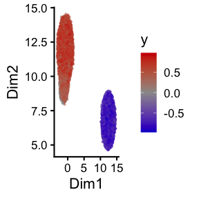

```r
dimplotCoords(coords = reducedDim(demo, "X_umap"),
              y = res$ncorrs,
              threshold = res$fdr_5p_t)
```

In the plot above, each cell is colored according to its neighborhood coefficient, i.e., color corresponds to the correlation of abundance in each cell’s corresponding neighborhood to case/control status. Neighborhoods that don’t pass FDR 5% are shown in gray. As this plot shows, cases have a greater abundance of cells from the left-hand cluster relative to controls.

### Analyze a More Sophisticated Phenotype

Next, perform an association test for male/female sex rather than case/control status.

```r
res <- association(data = rcna_data,
                   y = "male",
                   batches = "batch",
                   covs = "case",
                   verbose = FALSE)
```

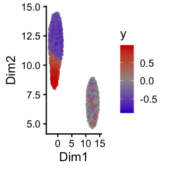

```r
dimplotCoords(coords = reducedDim(demo, "X_umap"),
              y = res$ncorrs,
              threshold = res$fdr_5p_t)
```

It’s now clear that a sub-population of the left-hand cluster is more abundant in males. CNA automatically picked up on this without needing to be given a resolution parameter.

Note that it looks like some cells in the right-hand cluster pass our FDR threshold of 5%. However, these cells comprise only ~6% of the cells that pass the threshold and so are likely false discoveries.

### Relate Results to Clusters

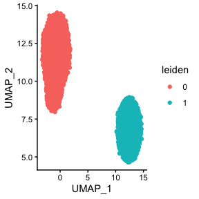

```r
cldata <- data.frame(reducedDim(demo, "X_umap"),
                     leiden = demo$leiden,
                     ncorrs = res$ncorrs)
colnames(cldata)[1:2] <- c("UMAP_1", "UMAP_2")

ggplot(cldata) +
    geom_point(aes(x = UMAP_1, y = UMAP_2, color = leiden)) +
    theme_classic()
```

We can examine within-cluster heterogeneity characterized by CNA by visualizing the distribution of neighborhood coefficients within each cluster.

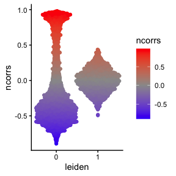

```r
ggplot(cldata) +
    geom_beeswarm(aes(x = leiden, y = ncorrs, color = ncorrs),
                              cex = 0.5) +
    scale_color_gradient2(low = "blue", mid = "gray60", high = "red") +
    theme_classic()
```

### Relate Results to Genes

To characterize the populations driving the association, we can examine per-gene correlations to neighborhood coefficient. These per-gene values may be informative on their own, or they could be further analyzed using techniques like gene set enrichment analysis.

```r
caseCorr <- cor(as.vector(res$ncorrs), t(assay(demo, "X"))) |>
    t() |>
    data.frame(cor = _)

arrange(caseCorr, cor) |> tail()
```

```
##               cor
## gene_4  0.1734456
## gene_5  0.1734643
## gene_1  0.1751399
## gene_9  0.1761101
## gene_11 0.1786859
## gene_10 0.1901941
```

```r
arrange(caseCorr, cor) |> head()
```

```
##                 cor
## gene_20 -0.10436048
## gene_21 -0.09415760
## gene_19 -0.08883475
## gene_22 -0.08874634
## gene_12 -0.08094196
## gene_24 -0.07870239
```